# Scripting in a reproducible environment – using git with RStudio and GitHub

3.14.2022

## Important note

```r
pi
```

```
## [1] 3.141593
```

```r
today <- 3.14
((pi - today) / today * 100) %>%
  round(digits = 5) %>%
  str_c("relative difference:", ., "%", sep = " ") %>%
  cat
```

```
## relative difference: 0.05072 %
```

## VCS, git – what and why?

- What is “version control”, and why should you care? Version control is a system that records changes to a file or set of files over time so that you can recall specific versions later. [Git book 1.1]
- It allows you to revert selected files back to a previous state, revert the entire project back to a previous state, compare changes over time, see who last modified something that might be causing a problem, who introduced an issue and when, and more. Using a VCS also generally means that if you screw things up or lose files, you can easily recover. In addition, you get all this for very little overhead. [Git book 1.1]
- `git` is a system (program) which is an example of VCS

## git vs GitHub

[figure not shown]

A version control system for creating repositories

[figure not shown]

Hosting service allowing users to keep their repositories and manage them there. There are numerous other examples of similar services, e.g. *GitLab* or *BitBucket*.

## Ways of interacting with git

Interacting with `git` is done by using *commands* (elementary actions). There are several ways of interacting with `git`:

- *Command line interface (CLI)* – the most direct way.
- *Graphical user interface (GUI)* built-in in some programming environment ( *Visual Studio Code*, *JetBrains’ IDEs*, *RStudio*).
- Programmable interface – writing code in specific language using provided tools (*usethis* R package).
- External desktop apps (*SourceTree*, *GitKraken*).
- Website apps (*GitHub* website).

## Basic git definitions

- Repository – a copy of files of which the project consists.
- Local/Remote – repository present on current machine/repository available via the network.
- Diff – a change between two versions of the same file.
- Commit – a git object, a snapshot of your entire repository.
- SHA – hashed value of your commit, (almost) unique representation of your commit
- Stage/Index – changes in local repository marked as ready to be commited.
- Branch – a lightweight movable pointer to a commit.

## Git repo visualized

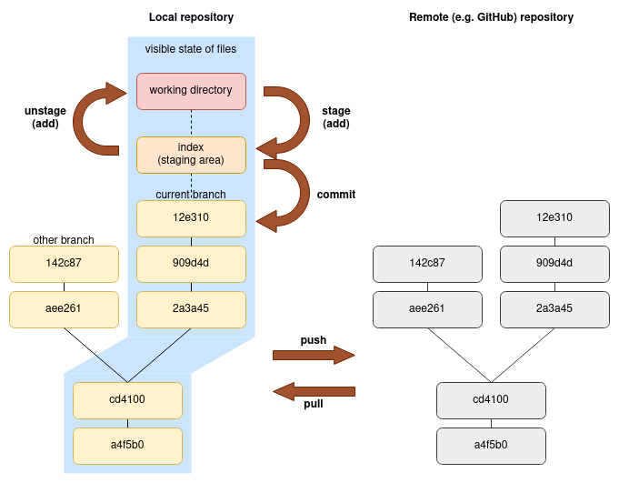

## RStudio git GUI

[figure not shown]

## RStudio git GUI

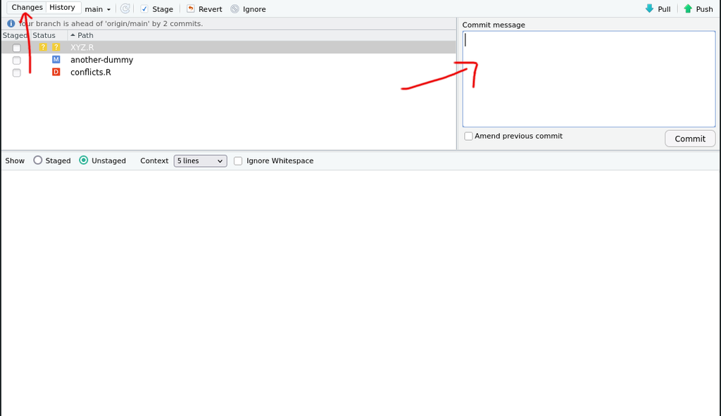

## RStudio git GUI

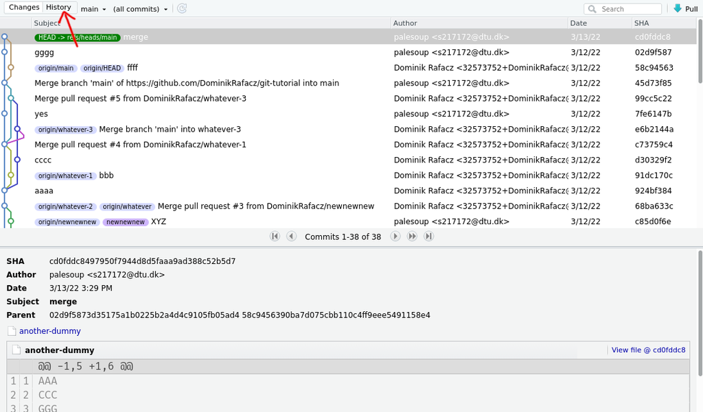

## RStudio git GUI

RStudio git GUI allows you to:

- Stage and commit changes.
- Browse through changes and compare files.
- Pull/push changes from/to remote repository.
- Revert changes.
- Create branches.

## GitHub website GUI

[figure not shown]

## GitHub website GUI

GitHub website allows you to:

- Browse through public repositories, their files and commits.
- **Set up new repositories.**
- **Clone a repository (create a new local from remote).**
- Fork a repository (create a new remote from remote).
- Upload/modify files (but you shouldn’t).
- Open issues (bug reports, feature suggestions, etc.).
- **Open and manage pull requests (merge branches within a repository and between repositories)**
- Do much more cool things.

## A few words on branching

Some repos don’t use branches at all…

[figure not shown]

## A few words on branching

… while other employ branching heavilly.

[figure not shown]

## A few words on branching

There are a few *branching strategies* which determine how branches are created and maintained within a project. There is no one universal best system, their usefulness usually depends on the project.

- Single branch: main.
- Main + one branch per team member.
- Main + one branch per functionality fix/change (trunk-based workflow).
- Main + devel + releases + features + fixes (git flow workflow).

## Popular branching strategies: one branch

Repository with a single branch. All commits to *main*

Suitable for: small projects maintained by one person (my masters) or *very small*, short term projects by two-three person

## Popular branching strategies: team member branches

Repository with a single *main* branch and one branch per each team member. Everyone works on their changes and then merge it into *main* and merge *main* into their branch to work further.

Suitable for: small/medium projects performed by by small teams without a need of constantly presetning the results of the projects to the client.

## Popular branching strategies: trunk-based workflow

Repository with a single core *trunk* or *main* branch. A lot of small branches (adding and integrating one function, one step of workflow, one bugfix, one document, etc.) are constantly created, merged and deleted.

Suitable for: same as above (it is actually easier to maintain!); also suitable for medium and bigger open-source projects and the professional ones (web applications, R packages)

## Popular branching strategies: trunk-based workflow

[figure not shown]

(source: [toptal](https://www.toptal.com/software/trunk-based-development-git-flow))

## Popular branching strategies: git flow workflow

The most advanced workflow:

- *Main* branch containing current “official”, representative version of the project, which is publicly available and possibly installed in the production environment.
- *Devel* branch containing the development version, not necessarily ready and tested, but including changes to be further merged into *main*.
- *Feature* branches containing single functionalities, later merged into *devel*.
- *Hotfix* branches merged directly into *main*, being the results of fixing bugs found in already deployed solution.
- *Release* branches being the step in between *devel* and *main*.

Suitable for: mostly for big teams with solutions which need constant deployment and integration; recently losing popularity to the previous solution.

## Popular branching strategies: git flow workflow

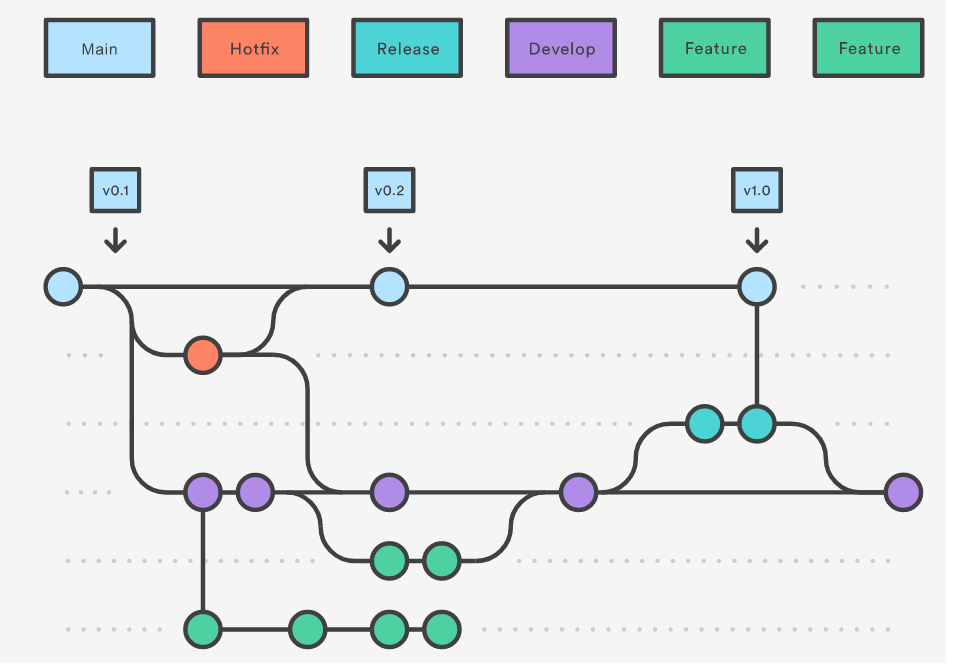

(source: [bit bucket](https://www.atlassian.com/git/tutorials/comparing-workflows/gitflow-workflow))

## Your turn!

Go and play with the exercises!